# Análise exploratória dos dados do TravisTorrent

## Introdução

O [Travis](https://travis-ci.org/) é um serviço de [integração contínua](https://en.wikipedia.org/wiki/Continuous_integration) utilizado para construir e testar *softwares* hospedados no GitHub, um sistema de controle de versão que utiliza o [git](https://en.wikipedia.org/wiki/Git). Nesta análise iremos explorar os dados do TravisTorrent, uma base de dados que contém informações de repositórios públicos do GitHub, bem como dados de log do Travis do respectivo projeto.

Primeiramente vamos importar as bibliotecas utilizadas nesta análise, bem como os dados que utilizaremos na mesma:

```r
library(tidyverse)
projetos <- read_csv("data/projetos.csv")
```

Vejamos a estrutura dos dados:

```r
projetos %>%
  str()
```

```
## Classes 'tbl_df', 'tbl' and 'data.frame':    1274 obs. of  16 variables:
##  $ gh_project_name      : chr  "47deg/appsly-android-rest" "abarisain/dmix" "AChep/AcDisplay" "activeadmin/activeadmin" ...
##  $ team                 : num  6 7 3 19 2 13 4 3 3 8 ...
##  $ lang                 : chr  "java" "java" "java" "ruby" ...
##  $ sloc_end             : int  3741 43665 27734 7029 2713 3629 3081 9325 4544 4094 ...
##  $ sloc_med             : num  2366 21096 21277 6759 2627 ...
##  $ activity_period      : int  10 35 20 28 24 36 12 12 17 47 ...
##  $ num_commits          : int  97 1588 1146 8579 247 46836 6979 2301 120 1195 ...
##  $ commits_per_month    : num  9.7 45.4 57.3 306.4 10.3 ...
##  $ tests_per_kloc       : num  3.417 4.831 0.302 130.547 72.527 ...
##  $ total_builds         : int  137 642 488 5870 253 27037 3085 1803 84 611 ...
##  $ build_success_prop   : num  0.0292 0.8489 0.4262 0.775 0.668 ...
##  $ builds_per_month     : num  13.7 18.3 24.4 209.6 10.5 ...
##  $ tests_added_per_build: num  0.00321 0 0 0 0 ...
##  $ tests_successful     : num  NaN NaN NaN 0.998 1 ...
##  $ test_density         : num  0.784 0 0.151 127.575 52.256 ...
##  $ test_size_avg        : num  34.32 0.99 6.29 8.34 9.48 ...
##  - attr(*, "spec")=List of 2
##   ..$ cols   :List of 16
##   .. ..$ gh_project_name      : list()
##   .. .. ..- attr(*, "class")= chr  "collector_character" "collector"
##   .. ..$ team                 : list()
##   .. .. ..- attr(*, "class")= chr  "collector_double" "collector"
##   .. ..$ lang                 : list()
##   .. .. ..- attr(*, "class")= chr  "collector_character" "collector"
##   .. ..$ sloc_end             : list()
##   .. .. ..- attr(*, "class")= chr  "collector_integer" "collector"
##   .. ..$ sloc_med             : list()
##   .. .. ..- attr(*, "class")= chr  "collector_double" "collector"
##   .. ..$ activity_period      : list()
##   .. .. ..- attr(*, "class")= chr  "collector_integer" "collector"
##   .. ..$ num_commits          : list()
##   .. .. ..- attr(*, "class")= chr  "collector_integer" "collector"
##   .. ..$ commits_per_month    : list()
##   .. .. ..- attr(*, "class")= chr  "collector_double" "collector"
##   .. ..$ tests_per_kloc       : list()
##   .. .. ..- attr(*, "class")= chr  "collector_double" "collector"
##   .. ..$ total_builds         : list()
##   .. .. ..- attr(*, "class")= chr  "collector_integer" "collector"
##   .. ..$ build_success_prop   : list()
##   .. .. ..- attr(*, "class")= chr  "collector_double" "collector"
##   .. ..$ builds_per_month     : list()
##   .. .. ..- attr(*, "class")= chr  "collector_double" "collector"
##   .. ..$ tests_added_per_build: list()
##   .. .. ..- attr(*, "class")= chr  "collector_double" "collector"
##   .. ..$ tests_successful     : list()
##   .. .. ..- attr(*, "class")= chr  "collector_double" "collector"
##   .. ..$ test_density         : list()
##   .. .. ..- attr(*, "class")= chr  "collector_double" "collector"
##   .. ..$ test_size_avg        : list()
##   .. .. ..- attr(*, "class")= chr  "collector_double" "collector"
##   ..$ default: list()
##   .. ..- attr(*, "class")= chr  "collector_guess" "collector"
##   ..- attr(*, "class")= chr "col_spec"
```

Vemos que existem 16 variáveis nos dados:

- gh_project_name: o nome do projeto
- team: a mediana do tamanho do time no decorrer do projeto
- lang: a linguagem predominante do projeto na última medição
- sloc_end: a quantidade máxima de linhas de código durante as medições do projeto
- sloc_med: a quantidade mediana de linhas de código durante as medições do projeto
- activity_period: a quantidade de meses de atividade do projeto
- num_commits: a quantidade de commits do projeto
- commits_per_month: número de commits por mês
- tests_per_kloc: quantidade máxima de testes no decorrer do projeto
- total_builds: número total de buils
- build_success_prop: proporção de builds que tiveram sucesso
- builds_per_month: número de builds por mês
- tests_added_per_build: número de testes por linha de código
- tests_successful: proporção média de testes que tiveram sucesso
- test_density: quantidade mediana de casos de testes por mil linhas de código
- test_size_avg: número médio de linhas por caso de teste

## Tamanho dos times

Vejamos inicialmente como se comportam os dados do tamanho do time:

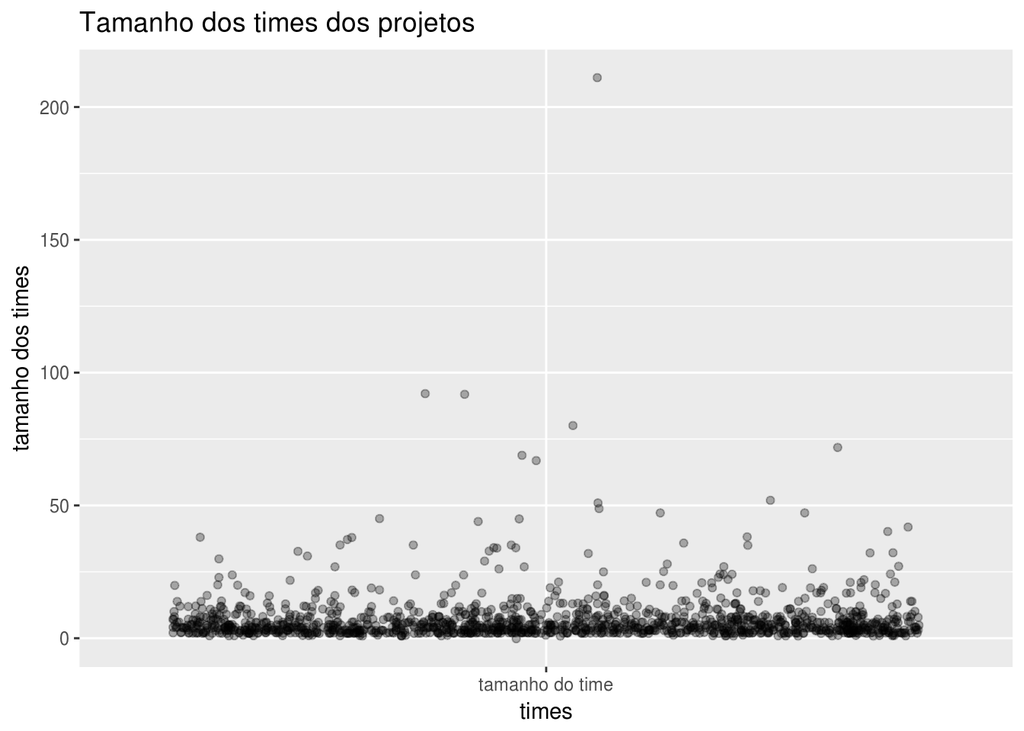

```r
projetos %>%
  ggplot(aes(x = "tamanho do time", y = team)) +
    geom_jitter(alpha = 0.3) +
  labs(x = "times", y = "tamanho dos times", title = "Tamanho dos times dos projetos")
```

Podemos ver que a maior parte dos times tem tamanho pequeno, menor que 25, onde a mediana é 5 e os tamanhos dos times vão de 0 à 211.

Vejamos a distribuição destes dados de forma mais sintetizada:

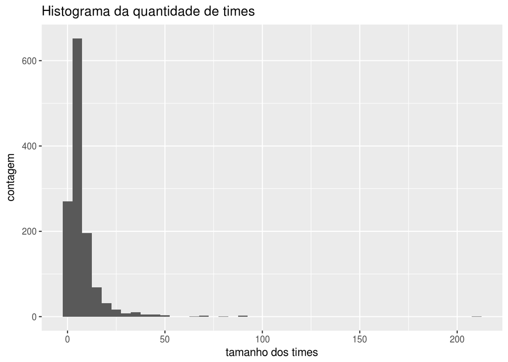

```r
projetos %>%
  ggplot(aes(x = team)) +
  geom_histogram(binwidth = 5) +
  labs(x = "tamanho dos times", y = "contagem", title = "Histograma da quantidade de times")
```

Vemos que realmente a maior parte dos projetos tem tamanhos de times pequenos, visto que os dados são enviesados à direita.

### Tamanho dos times por linguagem

Vejamos agora se existe diferença entre o tamanho dos times quando variamos a linguagem entre java e ruby:

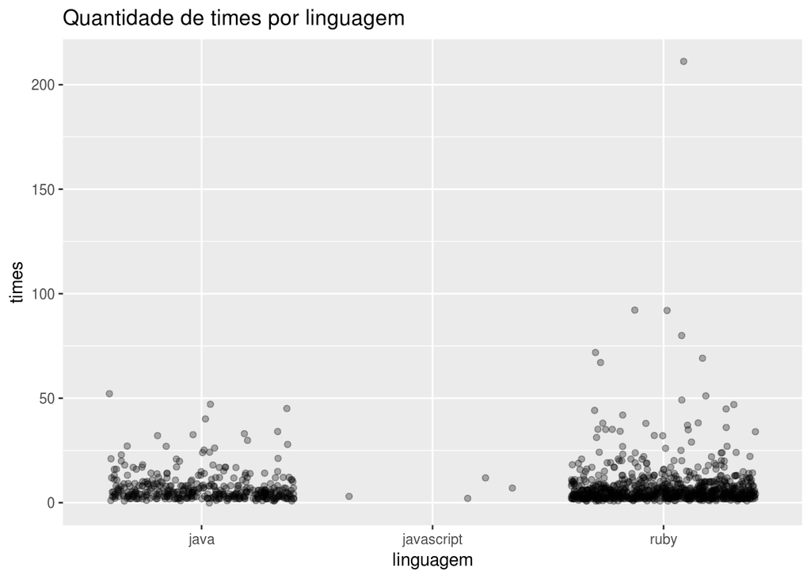

```r
projetos %>%
  ggplot(aes(x = lang, y = team)) +
  geom_jitter(alpha = 0.3) +
  labs(x = "linguagem", y = "times", title = "Quantidade de times por linguagem")
```

Vemos que em ambas linguagens a maior parte dos projetos tem times pequenos, porém notamos também que existem 4 projetos que foram feitos em javascript. Vejamos quais são estes:

```r
projetos %>%
  filter(lang == "javascript") %>%
  select(gh_project_name)
```

| gh_project_name |
| --- |
| brooklyncentral/clocker |
| dianping/cat |
| palantir/eclipse-typescript |
| zhangkaitao/es |

Pesquisando no github, dois projetos estão descritos em chinês, enquanto outros dois não parecem tem linguagem muito bem definida. Com isso, descartaremos estas observações.

```r
projetos.filt <- projetos %>%
  filter(lang != "javascript")
```

Vejamos como se comportam os dados os dados de tamanho de times de java e ruby em mais alto nível:

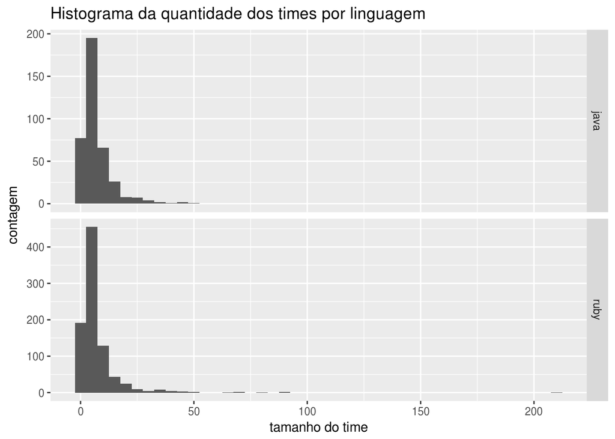

```r
projetos.filt %>%
  ggplot(aes(x = team)) +
    geom_histogram(binwidth = 5) +
    facet_grid(lang ~ ., scales = "free_y") +
    labs(x = "tamanho do time", y = "contagem", title = "Histograma da quantidade dos times por linguagem")
```

Os dados tem uma distribuição muito semelhante, visto que ambos são bastante assimétricos e enviesados à direita. Além disso, a faixa de valores entre 5 e 10 contém expressivamente mais projetos que as demais, bem como a faixa entre 0 e 5 tem valor um pouco maior que a faixa entre 10 e 15.

```r
projetos.filt %>%
  group_by(lang) %>%
  summarise(mediana = median(team))
```

| lang | mediana |
| --- | --- |
| java | 5 |
| ruby | 5 |

Apesar de existirem mais valores extremos em ruby do que em java, a mediana do tamanho do time em ambas linguagens é 5. Com isso, concluímos que não existe diferença significativa do tamanho dos times entre as linguagens ruby e java nos dados apresentados.

## Builds com sucesso

Vejamos agora a proporção de sucesso dos builds nos diferentes projetos:

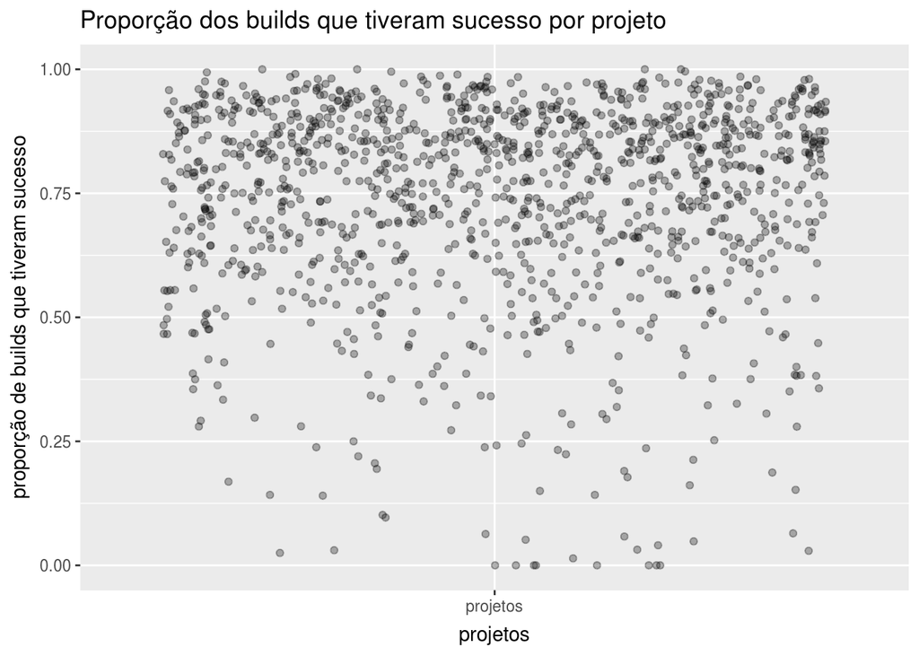

```r
projetos.filt %>%
  ggplot(aes(x = "projetos", y = build_success_prop)) +
    geom_jitter(alpha = 0.3) +
    labs(x = "projetos", y = "proporção de builds que tiveram sucesso", title = "Proporção dos builds que tiveram sucesso por projeto")
```

Vemos que a maior parte dos projetos tem proporção de builds que deram sucesso acima de 0.5, onde a mediana é 0.796196 e os valores vão de 0 à 1.

Vejamos agora se existe relação entre a proporção de builds que tiveram sucesso e o tamanho do time:

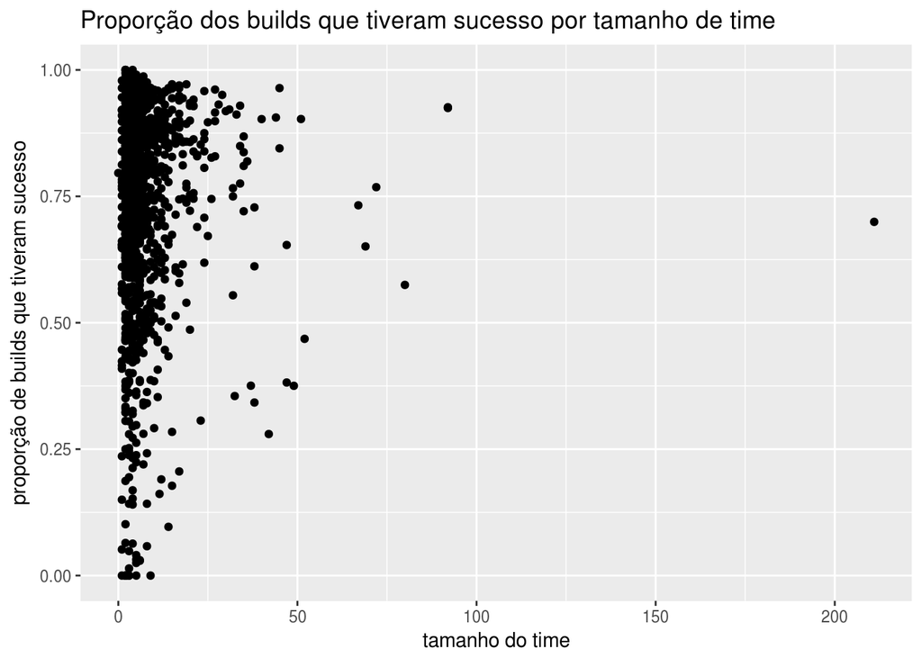

```r
projetos.filt %>%
  ggplot(aes(x = team, y = build_success_prop)) +
    geom_point() +
    labs(x = "tamanho do time", y = "proporção de builds que tiveram sucesso", title = "Proporção dos builds que tiveram sucesso por tamanho de time")
```

Podemos perceber que projetos de até 10 integrantes não parece existir uma relação entre as duas variáveis, mas acima deste valor, parece existir uma tendência crescente. Vejamos se isso realmente se confirma:

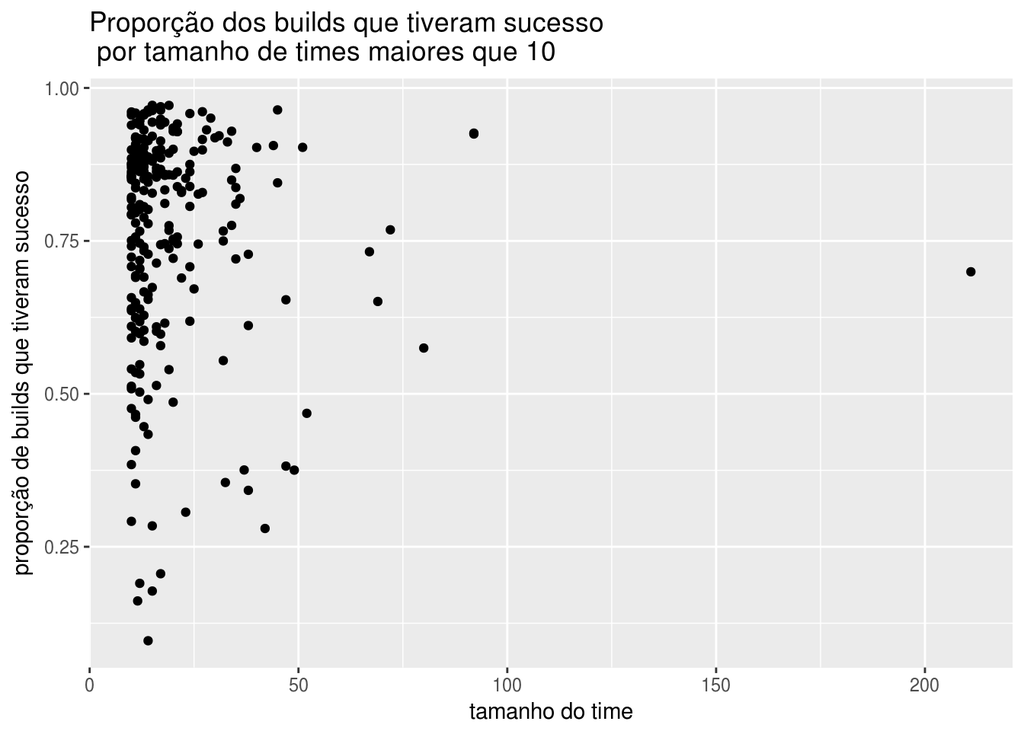

```r
projetos.times.maiores.10 <- projetos.filt %>%
  filter(team >= 10)

projetos.times.maiores.10%>%
  ggplot(aes(x = team, y = build_success_prop)) +
    geom_point() +
    labs(x = "tamanho do time", y = "proporção de builds que tiveram sucesso", title = "Proporção dos builds que tiveram sucesso\n por tamanho de times maiores que 10")
```

Apesar de existir um afunilamento com tendência crescente, a relação entre as duas variáveis não é muito expressiva, como podemos ver a seguir:

```r
cor(projetos.times.maiores.10 %>% pull(team), projetos.times.maiores.10 %>% pull(build_success_prop), method = "spearman")
```

```
## [1] 0.07027135
```

Vejamos se existe diferença da proporção dos builds que tiveram sucesso nas linguagens:

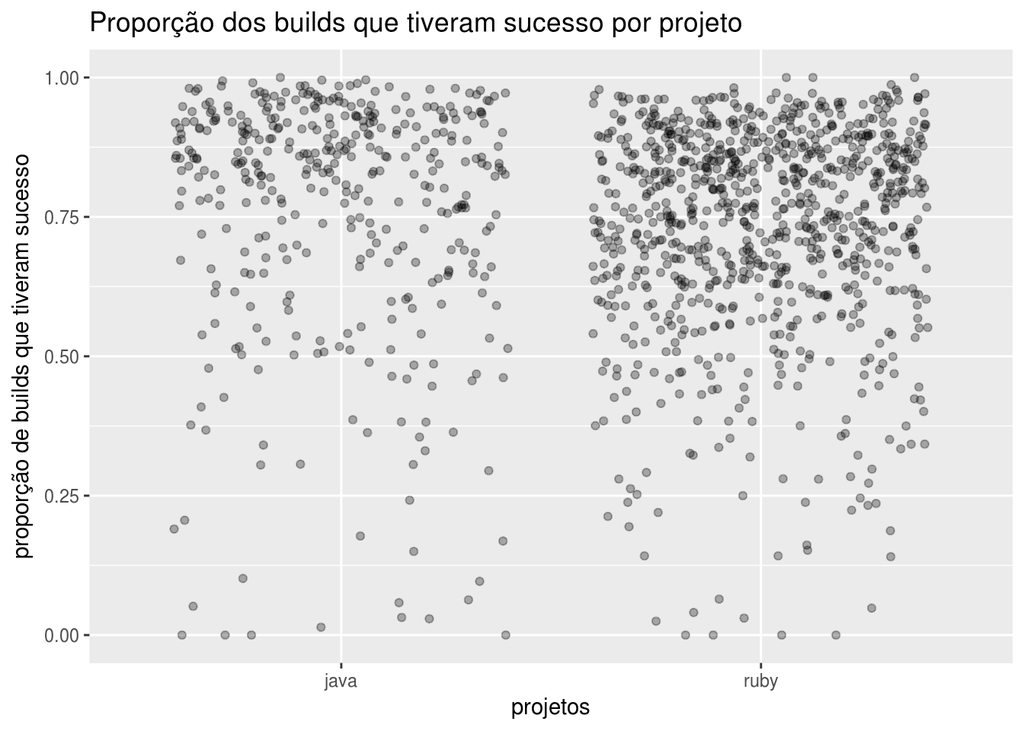

```r
projetos.filt %>%
  ggplot(aes(x = lang, y = build_success_prop)) +
    geom_jitter(alpha = 0.3) +
    labs(x = "projetos", y = "proporção de builds que tiveram sucesso", title = "Proporção dos builds que tiveram sucesso por projeto")
```

Parece existir uma ligeira diferença entre as linguagens, principalmente com relação a sua variação. Vejamos se isso se confirma em outra visualização:

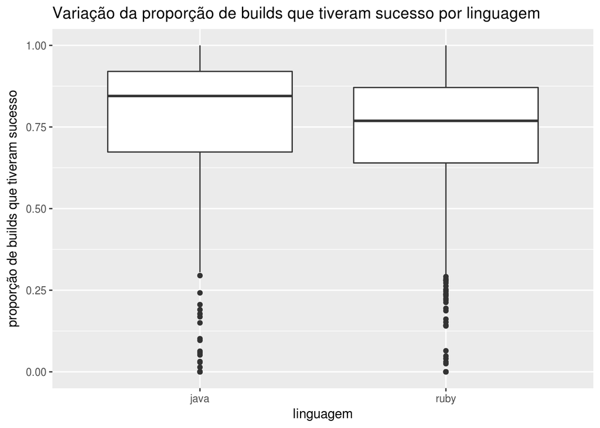

```r
projetos.filt %>%
  ggplot(aes(x = lang, y = build_success_prop)) +
    geom_boxplot() +
    labs(x = "linguagem", y = "proporção de builds que tiveram sucesso", title = "Variação da proporção de builds que tiveram sucesso por linguagem")
```

Não parece existir uma diferença muito significativa em suas variações. Vejamos se o afunilamento que verificamos anteriormente influencia na variação da proporção dos builds que tiveram sucesso. Para isso, continuaremos com a métrica de filtrar projetos que tem pelo menos 10 integrantes em seu time.

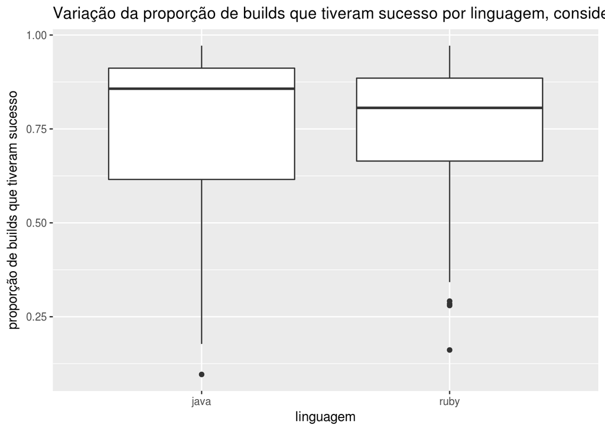

```r
projetos.times.maiores.10 %>%
  ggplot(aes(x = lang, y = build_success_prop)) +
    geom_boxplot() +
    labs(x = "linguagem", y = "proporção de builds que tiveram sucesso", title = "Variação da proporção de builds que tiveram sucesso por linguagem, considerando times maiores ou iguais a 10")
```

Vemos que a variação da proporção de builds que tiveram sucesso é maior em java do que em ruby, como podemos ver na tabela a seguir:

```r
projetos.times.maiores.10 %>%
  group_by(lang) %>%
  summarise(desvio.padrão.prop.build.success = sd(build_success_prop),
            media.prop.build.success = mean(build_success_prop))
```

| lang | desvio.padrão.prop.build.success | media.prop.build.success |
| --- | --- | --- |
| java | 0.2178318 | 0.7570042 |
| ruby | 0.1672815 | 0.7593909 |